# Network Distance with LION map

We will attempt to use networkx library with the lion map to calculate network distance for people walking between two points

- Download the zipfile
- Extract and save the zipfile
- Open the line shapefile
- Extract nodes
- Calculate network distance!

We will use the following libraries to achieve our purpose.

```python
import geopandas as gpd
import pandas as pd
import matplotlib.pyplot as plt
import networkx as nx
from shapely.geometry import box, LineString, Point,MultiPoint
import os
import sys
import requests
from zipfile import ZipFile as zzip
import fiona
from scipy.spatial import cKDTree
import numpy as np

sys.path.append(os.path.realpath('..'))
```

## Downloading and Extracting the NYC Lion file

- This does not need to be run repeatedly

```python
url = r"https://www1.nyc.gov/assets/planning/download/zip/data-maps/open-data/nyclion_19b.zip"

# download the file contents in binary format
r = requests.get(url)
# open method to open a file on your system and write the contents
with open("../input_data/nyclion_19b.zip", "wb") as file:
    file.write(r.content)
```

```python
fp = "../input_data/nyclion_19b.zip"
# opening the zip file in READ mode
with zzip(fp, 'r') as file:
    # printing all the contents of the zip file
    file.printdir()

    # extracting all the files
    #rint('Extracting all the files now...')
    file.extractall("../input_data/")
    print('Done!')
```

[output not shown]

[output cut: 23 more lines]

```
lion/LION - Roadbeds.lyr                       2017-02-10 07:49:32        24576
lion/LION - Nodes.lyr                          2012-08-17 13:19:50        11776
lion/LION - Street Direction Arrows (ArcGIS 10x).lyr 2013-01-15 10:58:06        22528
lion/LION - Street Direction Arrows (Requires Maplex).lyr 2013-03-12 14:22:44        22528
lion/TrafficRepArrows.style                    2012-09-27 08:32:40       598016
lion/ReadMe.txt                                2014-03-17 15:27:04         7758
altnames_metadata.html                         2019-05-13 12:49:22        38976
altnames_metadata.pdf                          2019-05-13 14:35:58       129541
lion_metadata.html                             2019-05-13 12:49:12       199830
lion_metadata.pdf                              2019-05-13 14:35:22       483768
node_metadata.html                             2019-05-13 12:49:32        42396
node_metadata.pdf                              2019-05-13 14:34:28       135027
node_stname_metadata.html                      2019-05-13 12:49:40        32999
node_stname_metadata.pdf                       2019-05-13 14:36:56       123835
Done!
```

Get layers from GDB

```python
gdb_file = r"../input_data/lion/lion.gdb"
layers = fiona.listlayers(gdb_file)
```

View the layers

```python
for layer in layers:
    print(layer)
```

```
node
node_stname
altnames
lion
```

## Open the lion layer

It was impossible to read in this layer with the old version of `Fiona`. Please ensure that your `Fiona` version is the most up to date.

```python
gdb_file = r"../input_data/lion/lion.gdb"
lion_gdf = gpd.read_file(gdb_file, driver='FileGDB', layer='lion')
```

```python
lion_gdf.crs
```

```
{'init': 'epsg:2263'}
```

```python
lion_gdf = lion_gdf.to_crs({'init': 'epsg:4326'})
```

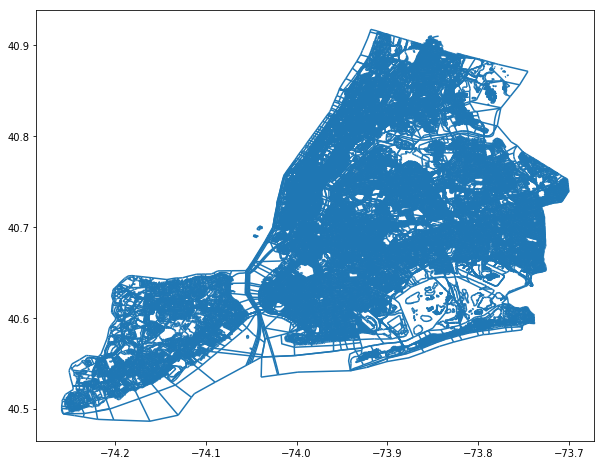

```python
lion_gdf.plot(figsize = (10,10));
```

We need to clean the `lion_gdf` a little so that non-pedestrians accessible routes are not included.

`FeatureTyp <> 'F' AND FeatureTyp <> '9' AND FeatureTyp <> '1' AND FeatureTyp <> '7' AND FeatureTyp <> '3' AND TrafDir <> '' AND NonPed <> 'V'`

Source: https://pointsunknown.nyc/tutorials/04_Q3_SpatialAnalysis.html

```python
lion_gdf['todrop'] = (lion_gdf['NonPed'] == 'V') |
                    (lion_gdf['FeatureTyp'].isin(['F','9','1','7','3'])) |
                    (lion_gdf['TrafDir'].isin([' ']))
```

```python
lion_gdf['todrop'].value_counts()
```

```
False    166475
True      60502
Name: todrop, dtype: int64
```

Save the clean version in a new dataframe

```python
clean_lion_gdf = gpd.GeoDataFrame(lion_gdf.loc[lion_gdf['todrop'] == False])
```

Checking that those observations were dropped

```python
(clean_lion_gdf['NonPed'] == 'V').value_counts()
```

```
False    166475
Name: NonPed, dtype: int64
```

```python
clean_lion_gdf['FeatureTyp'].isin(['F','9','1','7','3']).value_counts()
```

```
False    166475
Name: FeatureTyp, dtype: int64
```

```python
clean_lion_gdf['TrafDir'].isin([' ']).value_counts()
```

```
False    166475
Name: TrafDir, dtype: int64
```

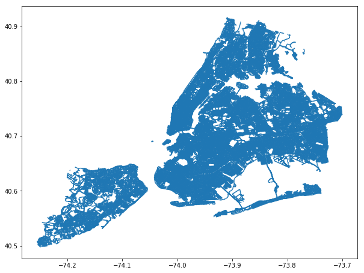

```python
clean_lion_gdf.plot(figsize=(10,10))
```

## Test case

We will use two points that are across from each other, but has a highway between them. The network analysis route should move along the road until it find a road that can cross under the highway.

To see the points:

Destination point: https://www.google.com/maps/place/40%C2%B044'13.9%22N+73%C2%B051'50.6%22W/@40.737199,-73.8662467,17z/data=!3m1!4b1!4m5!3m4!1s0x0:0x0!8m2!3d40.737199!4d-73.864058

Origin point: https://www.google.com/maps/place/40%C2%B043'56.9%22N+73%C2%B051'42.0%22W/@40.732484,-73.8638547,17z/data=!3m1!4b1!4m5!3m4!1s0x0:0x0!8m2!3d40.732484!4d-73.861666

```python
fp = r"../intermediate_data/clean_lion_line.shp"
lion_graph = nx.read_shp(fp)
```

```python
lion_graph
```

```
<networkx.classes.digraph.DiGraph at 0x1fbe3e6bf60>
```

This is the key to calculating the right network distance. The graph must be undirected for pedestrian distance.

```python
undirected_lion_graph = lion_graph.to_undirected()
```

```python
undirected_lion_graph
```

```
<networkx.classes.graph.Graph at 0x1fc0f464400>
```

Writing the Graph to shapefile creates the nodes and edges

```python
fp = r"../intermediate_data"
nx.write_shp(lion_graph, fp)
```

Read the `node` as geopandas dataframes

```python
fp = r"../intermediate_data/nodes.shp"
node_gdf = gpd.read_file(fp)
```

```python
node_gdf.crs = {'init': 'epsg:4326'}
```

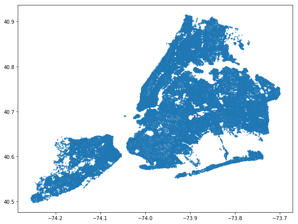

```python
node_gdf.plot(figsize=(10,10),markersize=1);
```

```python
target_xy = (-73.864058, 40.737199)
orig_xy = (-73.861666,40.732484)
```

We place the geometry of the `nodes` into the an numpy array and put the array into scipy's cKDTree. This turns the "index into a set of k-dimensional points which can be used to rapidly look up the nearest neighbors of any point." Super fast nearest-neighbor matching.

```python
nB = np.array(list(zip(node_gdf.geometry.x, node_gdf.geometry.y)) )
btree = cKDTree(nB)
```

Here we are finding the nearest node to our target_xy.

```python
dist, target_node = btree.query(target_xy,k=1)
print(dist, target_node)
```

```
3.7438436323677245e-05 66053
```

The distance measure above will be important for us to calculate the entire distance (distance from origin_xy to orgin_node + network distance + distance from target node to target_xy).

Lets view the node and the geometry of that node.

```python
node_gdf['geometry'].loc[node_gdf['FID'] == 66053]
```

```
66053    POINT (-73.86404739259665 40.73716309568955)
Name: geometry, dtype: object
```

Repeat for the origin node.

```python
dist, orig_node = btree.query(orig_xy,k=1)
print(dist, orig_node)
```

```
2.6730270855641812e-05 76256
```

```python
node_gdf['geometry'].loc[node_gdf['FID'] == 76256]
```

```
76256    POINT (-73.86164235281636 40.73247153733231)
Name: geometry, dtype: object
```

View the contents in the graph

```python
list(undirected_lion_graph.nodes)[0:10]
```

```
[(-73.90346685871668, 40.83035379646685),
 (-73.9023800533195, 40.82964662740077),
 (-73.9012006771837, 40.86661307824997),
 (-73.90207336386543, 40.866999105561305),
 (-73.90117669122948, 40.82438890917424),
 (-73.90050540472349, 40.826007622001576),
 (-73.90695663477764, 40.89360793519608),
 (-73.90695595783123, 40.89544764345081),
 (-73.90706510075327, 40.89927414148254),
 (-73.9071219824245, 40.89929111645273)]
```

In the `undirected_lion_graph`, the labels of the nodes are by default the coordinates. We will change it to intergers for ease of finding them.

```python
undirected_lion_graph = nx.convert_node_labels_to_integers(undirected_lion_graph, first_label = 0)
```

```python
list(undirected_lion_graph.nodes)[0:10]
```

```
[0, 1, 2, 3, 4, 5, 6, 7, 8, 9]
```

Checking that `undirected_lion_graph` has the nodes from above.

```python
#target node
undirected_lion_graph.has_node(target_node)
```

```
True
```

```python
#origin node
undirected_lion_graph.has_node(orig_node)
```

```
True
```

## Network analysis!

```python
route = nx.shortest_path(G=undirected_lion_graph, source=orig_node, target=target_node, weight = None)
```

Capture the route nodes and turn it into a `LineString`

```python
route_nodes = node_gdf.loc[route]
```

```python
route_line = LineString(list(route_nodes.geometry.values))
```

Make a geodataframe to store the data

```python
route_geom = gpd.GeoDataFrame(crs=node_gdf.crs)
route_geom['geometry'] = None
route_geom['id'] = None
```

Add the information into the geodataframe

```python
route_geom.loc[0, 'geometry'] = route_line
```

```python
route_geom.loc[0, 'id'] = str(list(route_nodes['FID'].values))
```

Now is the time to convert the data into `epsg 2263`.

```python
route_geom.crs
```

```
{'init': 'epsg:4326'}
```

```python
route_geom = route_geom.to_crs({'init': 'epsg:2263'})
```

Calculate network distance of the route!

```python
route_geom['length_ft'] = route_geom.length
route_geom['length_miles'] = route_geom['length_ft'] *0.000189394
```

```python
route_geom.head()
```

|  | geometry | id | length_ft | length_miles |
| --- | --- | --- | --- | --- |
| 0 | LINESTRING (1022595.221231206 206165.993610297... | [76256, 58177, 66289, 76111, 72542, 72541, 813... | 2893.217327 | 0.547958 |

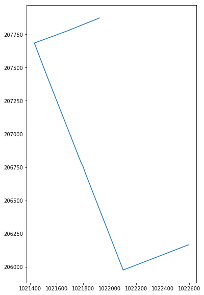

```python
route_geom.plot(figsize = (10,10));
```